# EFFECTS OF LOAN FEATURES ON LOAN STATUS

## Investigation Overview

In this dataset i will be investigating the features that will predict the Loan Status of a Loan Borrower. The features i will be looking into are : ListingCreationDate, Term, LoanStatus, BorrowerRate,ProsperRating (Alpha), ListingCategory (numeric), Occupation, EmploymentStatus,IsBorrowerHomeowner,DelinquenciesLast7Years,StatedMonthlyIncome,LoanKey,OnTimeProsperPayments,LoanOriginalAmount.

## Dataset Overview

The dataset has 113937 observations and 81 observations. all the missing valus were filled appropriately and inconsistencies were dealt with properly.

## Distribution Delinquencies Of Last 7Years and OnTimeProsperPayments of Borrowers

The distribution of Delinquency of Last Seven Years is between 0 but not up to 100,it was necessary for me to use a function to override the negative values on the x axis.The distribution seems unimodal and very right skewed. The Distribution of On Time Prosper Payments is also most likely Unimodal with some some peaks just immediately after 25 point,it is right skewed with its maximum just a step above 100.

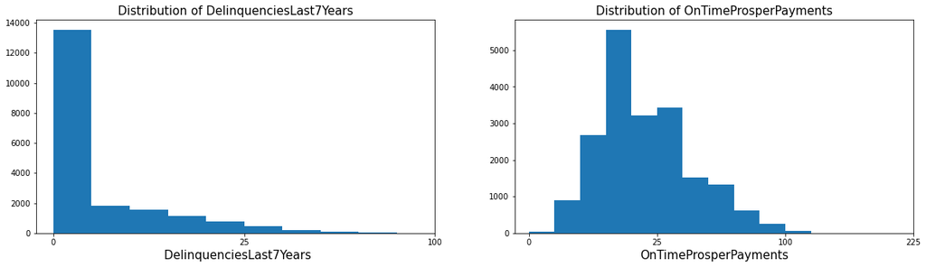

## Relationship Between Loan Status and Prosper Rating

The Relationship Between Loan Status and Prosper Rating considering only the "Current" and "Completed" Loan Status is strongest at Loan Status "Current and Rating "A" with least Correlation at Loan Status "Current" and Rating "HR" The Bar Chart to the right has it that the Rating A has the highest Count of above 2500 for Current Loan Status and Between 1000 and 1500 for the Complete Loan Status.

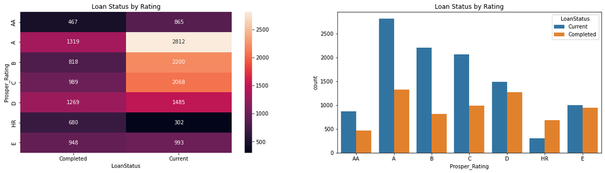

## Borrower Rate by Loan Status and Home Owner

Borrowers with defaulted Loan Status who have no home have the highest borrower rate above 0.25 and those with home have a borrower Rate above 0.225 but not up to 0.25. The Fianl Payment In Progess Loan Status without Home have higher borrower rate than those with home.

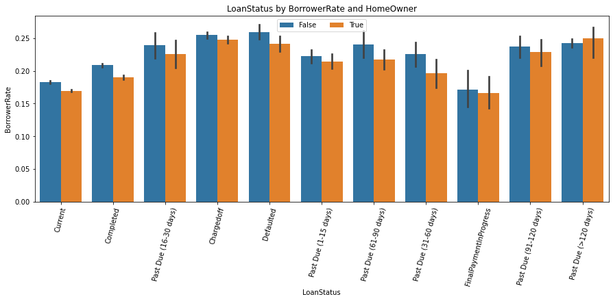

## Relationship Between Amount of Loan, Monthly Income and Loan Status

Borrowers with Current Loan Status have more Monthly Income than the completed,with more concentration and spread between loan amount of 1000 and 25000.

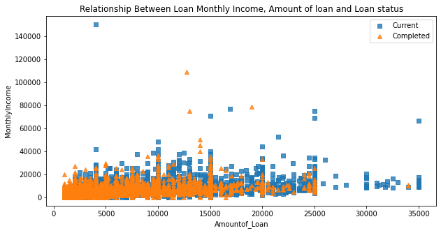

## Relationship between Loan Status and Interest on amount borrowed

Chargedoff and Defaulted Loan Status have the highest distribution with respect to the borrower rate. with median positions above 0.25, Current and Final Payment In Progress have the least median positons with respect to the borrower rate. Borrowers with current loan status had more than 75% of 0.20 borrower rate, while Borrowers with loan status of completed have more than 75% of 0.25 borrower rate. Past Due(> 120 days) have median position between 0.20 and 0.25 borower rate.

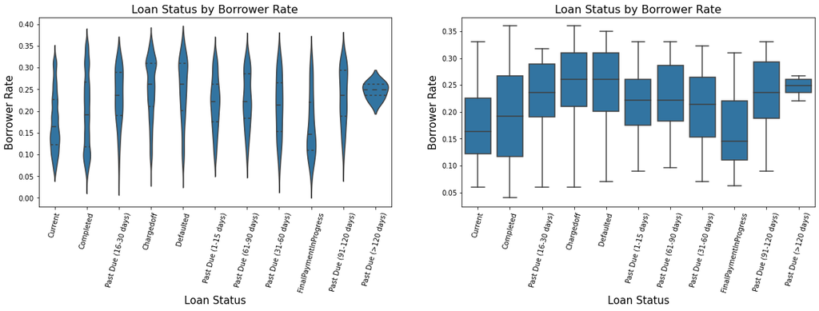